# Over-representation in R

Yasmin Hilliam, PhD

2025-06-29

### Over-representation analysis in R

This module will cover carrying out over-representation analysis in R. We will be using data from the `edgeR` module. The `lrt` object stores the result of the likelihood ratio test to identify differentially expressed genes.

```r
load("edgeR2024_lrt_object.Rdata")
```

```r
library(edgeR)
library(gplots)
library(tidyverse)
```

#### Fisher’s exact test

```r
Messymt <- matrix(c(299,208,178,315),
                  nrow = 2,
                  dimnames = list(
  Messy = c("Yes", "No"),
  Gender = c("Men", "Women")
))

Messymt # this is a Contingency table
```

```
     Gender
Messy Men Women
  Yes 299   178
  No  208   315
```

Alternative hypotheses:

1. the probability of men being Messy is different from women being Messy
2. the probability of men being Messy is greater than women being Messy
3. the probability of men being Messy is less than women being Messy

We will use function `fisher.test` to test the independence of two nominal variables - Messy (Yes/No) and gender (Men/Women)

Alternative hypothesis 1:

```r
fisher.test(Messymt,
            alternative = "two.sided")
```

```
    Fisher's Exact Test for Count Data

data:  Messymt
p-value = 4.374e-13
alternative hypothesis: true odds ratio is not equal to 1
95 percent confidence interval:
 1.955115 3.310313
sample estimates:
odds ratio
  2.541431
```

Alternative hypothesis 2:

```r
fisher.test(Messymt,
            alternative = "greater")
```

```
    Fisher's Exact Test for Count Data

data:  Messymt
p-value = 2.856e-13
alternative hypothesis: true odds ratio is greater than 1
95 percent confidence interval:
 2.036071      Inf
sample estimates:
odds ratio
  2.541431
```

Alternative hypothesis 3:

```r
fisher.test(Messymt,
            alternative = "less")
```

```
    Fisher's Exact Test for Count Data

data:  Messymt
p-value = 1
alternative hypothesis: true odds ratio is less than 1
95 percent confidence interval:
 0.000000 3.176384
sample estimates:
odds ratio
  2.541431
```

Tom Hampton and Todd MacKenzie will cover more about contingency tables and statistics in another session.

Now let’s build a contingency table for pathway enrichment analysis.

```r
read.table(file = "InnateImmune.txt") -> innate
```

Currently this is imported as a dataframe with only one variable, but we want these data as a vector

```r
innate$V1 -> innate_vec

head(innate_vec)
```

```
[1] "ENSG00000000971" "ENSG00000004139" "ENSG00000005339" "ENSG00000006210" "ENSG00000007171"
[6] "ENSG00000008018"
```

```r
length(innate_vec) # there are 561 genes in this list
```

```
[1] 561
```

Import `edgeR` data

```r
read.csv("log2FC_PA_vs_Untreated.csv") -> edgeR_data

head(edgeR_data)
```

|  | ENSEMBL | SYMBOL | GENENAME | logFC | logCPM | LR | PValue | FDR |
| --- | --- | --- | --- | --- | --- | --- | --- | --- |
| 1 | ENSG00000000003 | TSPAN6 | tetraspanin 6 | -0.2474122 | 7.009937 | 1.6168065 | 0.20353765 | 0.5013365 |
| 2 | ENSG00000000419 | DPM1 | dolichyl-phosphate mannosyltransferase subunit 1, catalytic | -0.1576061 | 5.311009 | 0.6908382 | 0.40587942 | 0.7104398 |
| 3 | ENSG00000000457 | SCYL3 | SCY1 like pseudokinase 3 | -0.2693685 | 4.392924 | 2.1367776 | 0.14380368 | 0.4133499 |
| 4 | ENSG00000000460 | FIRRM | FIGNL1 interacting regulator of recombination and mitosis | -0.3229852 | 2.266035 | 1.2809116 | 0.25772960 | 0.5665021 |
| 5 | ENSG00000000971 | CFH | complement factor H | -0.1850915 | 7.431878 | 0.7980821 | 0.37166741 | 0.6801424 |
| 6 | ENSG00000001036 | FUCA2 | alpha-L-fucosidase 2 | -0.3129195 | 5.096837 | 4.1755311 | 0.04101171 | 0.2032865 |

Now let’s identify upregulated differentially expressed genes (log2 fold change > 0 and FDR < 0.05)

|  | ENSEMBL | SYMBOL | GENENAME | logFC | logCPM | LR | PValue | FDR |
| --- | --- | --- | --- | --- | --- | --- | --- | --- |
| 1 | ENSG00000001084 | GCLC | glutamate-cysteine ligase catalytic subunit | 1.3179552 | 8.869286 | 24.41470 | 7.767369e-07 | 4.635206e-05 |
| 2 | ENSG00000001167 | NFYA | nuclear transcription factor Y subunit alpha | 0.5404390 | 5.702727 | 10.59494 | 1.133975e-03 | 1.735470e-02 |
| 3 | ENSG00000002587 | HS3ST1 | heparan sulfate-glucosamine 3-sulfotransferase 1 | 0.8894188 | 5.914526 | 12.89177 | 3.300295e-04 | 6.758210e-03 |
| 4 | ENSG00000003137 | CYP26B1 | cytochrome P450 family 26 subfamily B member 1 | 2.2614158 | 5.267937 | 28.95822 | 7.395626e-08 | 6.258108e-06 |
| 5 | ENSG00000003400 | CASP10 | caspase 10 | 1.5543223 | 5.888347 | 15.24291 | 9.453105e-05 | 2.588759e-03 |
| 6 | ENSG00000003402 | CFLAR | CASP8 and FADD like apoptosis regulator | 1.8274760 | 8.621504 | 75.88934 | 3.000159e-18 | 5.331283e-15 |

This has filtered the full dataframe to only those genes that are significantly upregulated. Let’s extract a vector of the Ensembl IDs.

```r
up_DEGs$ENSEMBL -> up_DEGs_vec
```

As well as a vector of all genes detected in the RNAseq experiment

```r
edgeR_data$ENSEMBL -> all_genes_vec

length(all_genes_vec)
```

```
[1] 16501
```

Now let’s use a Venn diagram to visualize the number of genes that are upregulated and included in the innate immunity dataset to build our contingency table.

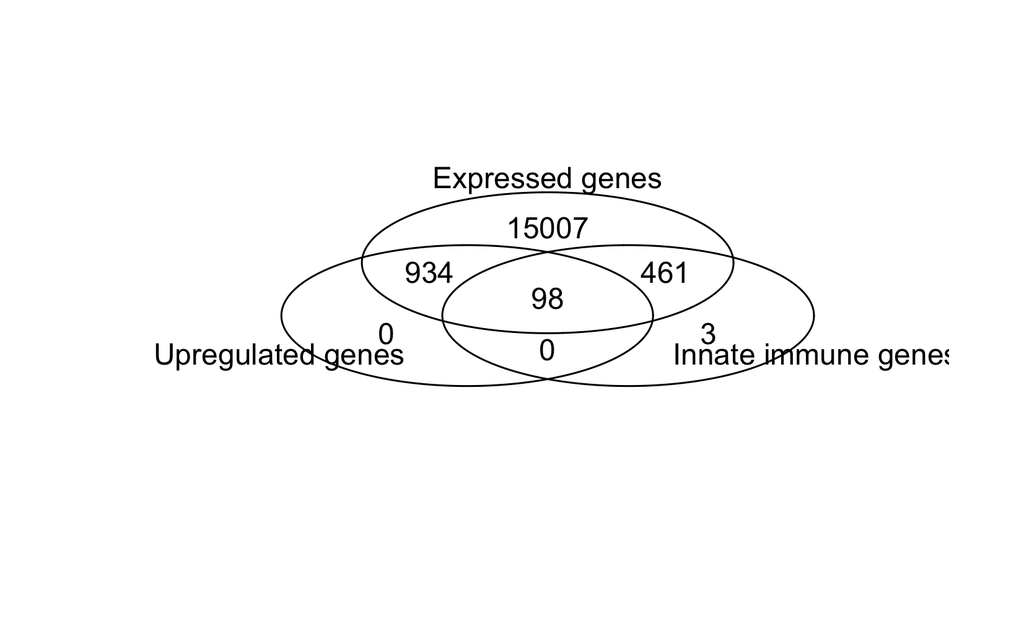

```r
venn(list("Upregulated genes" = up_DEGs_vec,
          "Innate immune genes" = innate_vec,
          "Expressed genes" = all_genes_vec))
```

```r
values <- c(length(intersect(OnPath,Upregulated)), # get number of upregulated immune genes
            length(intersect(OnPath,NotRegulated)), # unregulated immune genes
            length(intersect(NotOnPath,Upregulated)), # upregulated non immune genes
            length(intersect(NotOnPath,NotRegulated))) # unregulated non immune genes
```

```r
matrix(values, nrow = 2,
       dimnames = list(
         Upregulated = c("Yes","No"),
         OnPath = c("Yes","No")
       )) -> innate_immune_path_matrix

innate_immune_path_matrix
```

```
           OnPath
Upregulated Yes    No
        Yes  97   926
        No  461 14509
```

Now that we have generated our contingency table, we can run our Fisher’s exact test

```r
fisher.test(innate_immune_path_matrix,
            alternative = "greater")
```

```
    Fisher's Exact Test for Count Data

data:  innate_immune_path_matrix
p-value < 2.2e-16
alternative hypothesis: true odds ratio is greater than 1
95 percent confidence interval:
 2.695582      Inf
sample estimates:
odds ratio
  3.296432
```

Our P value is < 0.05 so the probability of finding regulated genes is higher among the specified gene list (our innate immune gene list) than in the genes outside of that list. This means that the pathway is over-represented and that the gene set is significantly enriched.

As you can see, this is still a long-winded way of doing this analysis but fortunately different contributors have made ways to extract all gene lists from a GO or KEGG database from an `edgeR` output and run Fisher’s exact test on all your pathways of interest.

```r
if (!requireNamespace("BiocManager", quietly = TRUE))
  install.packages("BiocManager")

BiocManager::install(c("GO.db","goana"))
n

library(GO.db)
library(org.Hs.eg.db)
```

Now we’ll use the `lrt` object we loaded at the beginning from `edgeR`

|  | genes |
| --- | --- |
| ENSG00000000003 | ENSG00000000003 |
| ENSG00000000419 | ENSG00000000419 |
| ENSG00000000457 | ENSG00000000457 |
| ENSG00000000460 | ENSG00000000460 |
| ENSG00000000971 | ENSG00000000971 |
| ENSG00000001036 | ENSG00000001036 |
| ENSG00000001084 | ENSG00000001084 |
| ENSG00000001167 | ENSG00000001167 |
| ENSG00000001460 | ENSG00000001460 |
| ENSG00000001461 | ENSG00000001461 |

[output cut: 990 more lines]

All the genes are annotated with Ensembl gene IDs but GO terms use ENTREZID, so we need to add ENTREZIDs to our `lrt` object.

| genes | ENTREZID | SYMBOL | GENENAME |
| --- | --- | --- | --- |
| ENSG00000000003 | 7105 | TSPAN6 | tetraspanin 6 |
| ENSG00000000419 | 8813 | DPM1 | dolichyl-phosphate mannosyltransferase subunit 1, catalytic |
| ENSG00000000457 | 57147 | SCYL3 | SCY1 like pseudokinase 3 |
| ENSG00000000460 | 55732 | FIRRM | FIGNL1 interacting regulator of recombination and mitosis |
| ENSG00000000971 | 3075 | CFH | complement factor H |
| ENSG00000001036 | 2519 | FUCA2 | alpha-L-fucosidase 2 |
| ENSG00000001084 | 2729 | GCLC | glutamate-cysteine ligase catalytic subunit |
| ENSG00000001167 | 4800 | NFYA | nuclear transcription factor Y subunit alpha |
| ENSG00000001460 | 90529 | STPG1 | sperm tail PG-rich repeat containing 1 |
| ENSG00000001461 | 57185 | NIPAL3 | NIPA like domain containing 3 |

[output cut: 990 more lines]

Now the `lrt` object is ready for pathway analysis using `goana` which is a wrapper function provided for `edgeR`

```r
goana(lrt,
      geneid = lrt$genes$ENTREZID,
      species = "Hs",
      FDR = 0.05) -> goana_res

str(goana_res)
```

```
'data.frame':   20960 obs. of  7 variables:
 $ Term  : chr  "immune system process" "regulation of immune system process" "immune response-regulating signaling pathway" "immune response" ...
 $ Ont   : chr  "BP" "BP" "BP" "BP" ...
 $ N     : num  1822 1139 393 1223 4379 ...
 $ Up    : num  294 189 72 216 495 472 934 900 496 394 ...
 $ Down  : num  35 22 9 24 107 95 369 350 105 70 ...
 $ P.Up  : num  5.49e-51 6.29e-33 5.16e-15 2.23e-42 1.22e-42 ...
 $ P.Down: num  1 0.997 0.879 0.997 1 ...
```

```r
head(goana_res)
```

|  | Term | Ont | N | Up | Down | P.Up | P.Down |
| --- | --- | --- | --- | --- | --- | --- | --- |
| GO:0002376 | immune system process | BP | 1822 | 294 | 35 | 5.490722e-51 | 0.9997808 |
| GO:0002682 | regulation of immune system process | BP | 1139 | 189 | 22 | 6.292200e-33 | 0.9967540 |
| GO:0002764 | immune response-regulating signaling pathway | BP | 393 | 72 | 9 | 5.163652e-15 | 0.8785086 |
| GO:0006955 | immune response | BP | 1223 | 216 | 24 | 2.225613e-42 | 0.9970030 |
| GO:0007154 | cell communication | BP | 4379 | 495 | 107 | 1.223829e-42 | 0.9996308 |
| GO:0007165 | signal transduction | BP | 4039 | 472 | 95 | 5.285408e-44 | 0.9998476 |

```r
dim(goana_res)
```

```
[1] 20960     7
```

20960 GO terms have been identified, which are all gene sets! These will not all be significant and may not all be meaningful/important to your work.

It is important to note that these P values are not adjusted for multiple testing, so we need to manually do that ourselves using the Bejamini & Hochberg method (“BH” of “FDR”).

```r
p.adjust(goana_res$P.Up,
         method = "fdr") -> goana_res$P.Up.adj

p.adjust(goana_res$P.Down,
         method = "fdr") -> goana_res$P.Down.adj

head(goana_res)
```

|  | Term | Ont | N | Up | Down | P.Up | P.Down | P.Up.adj | P.Down.adj |
| --- | --- | --- | --- | --- | --- | --- | --- | --- | --- |
| GO:0002376 | immune system process | BP | 1822 | 294 | 35 | 5.490722e-51 | 0.9997808 | 1.150855e-46 | 1 |
| GO:0002682 | regulation of immune system process | BP | 1139 | 189 | 22 | 6.292200e-33 | 0.9967540 | 3.878957e-30 | 1 |
| GO:0002764 | immune response-regulating signaling pathway | BP | 393 | 72 | 9 | 5.163652e-15 | 0.8785086 | 6.680873e-13 | 1 |
| GO:0006955 | immune response | BP | 1223 | 216 | 24 | 2.225613e-42 | 0.9970030 | 3.588374e-39 | 1 |
| GO:0007154 | cell communication | BP | 4379 | 495 | 107 | 1.223829e-42 | 0.9996308 | 2.137621e-39 | 1 |
| GO:0007165 | signal transduction | BP | 4039 | 472 | 95 | 5.285408e-44 | 0.9998476 | 2.215643e-40 | 1 |

How many significantly upregulated processes are there? First let’s check the **unadjusted** P values and then see how the stringency is changed by adjusting for multiple measurements.

```r
dim(goana_res %>%
      filter(P.Up < 0.05 & Ont == "BP")) # 2547
```

```
[1] 2547    9
```

```r
dim(goana_res %>%
      filter(P.Up.adj < 0.05 & Ont == "BP")) # 1321
```

```
[1] 1321    9
```

How many upregulated GO terms are there in total?

```r
dim(goana_res %>%
      filter(P.Up.adj < 0.05)) # 1523
```

```
[1] 1523    9
```

Let’s dig in and find some GO terms of interest.

There is a `topGO` function to identify the top enriched GO terms

```r
topGO(goana_res)
```

|  | Term | Ont | N | Up | Down | P.Up | P.Down | P.Up.adj | P.Down.adj |
| --- | --- | --- | --- | --- | --- | --- | --- | --- | --- |
| GO:0002376 | immune system process | BP | 1822 | 294 | 35 | 5.490722e-51 | 0.9997808 | 1.150855e-46 | 1 |
| GO:0050896 | response to stimulus | BP | 6103 | 636 | 160 | 3.631593e-49 | 0.9994028 | 3.805910e-45 | 1 |
| GO:0048518 | positive regulation of biological process | BP | 4746 | 535 | 126 | 1.256006e-47 | 0.9940450 | 8.775294e-44 | 1 |
| GO:0006952 | defense response | BP | 1246 | 224 | 28 | 2.018989e-45 | 0.9819053 | 1.057950e-41 | 1 |
| GO:0007165 | signal transduction | BP | 4039 | 472 | 95 | 5.285408e-44 | 0.9998476 | 2.215643e-40 | 1 |
| GO:0048583 | regulation of response to stimulus | BP | 3086 | 394 | 70 | 7.777722e-44 | 0.9996265 | 2.717018e-40 | 1 |
| GO:0050789 | regulation of biological process | BP | 8344 | 767 | 246 | 1.003149e-43 | 0.9600958 | 3.003714e-40 | 1 |
| GO:0023052 | signaling | BP | 4370 | 496 | 105 | 2.566492e-43 | 0.9998174 | 6.724209e-40 | 1 |
| GO:0065007 | biological regulation | BP | 8637 | 783 | 252 | 3.968111e-43 | 0.9809166 | 9.241290e-40 | 1 |
| GO:0048522 | positive regulation of cellular process | BP | 4313 | 491 | 114 | 4.560299e-43 | 0.9919767 | 9.558386e-40 | 1 |

[output cut: 10 more lines]

However, this only selects the top 20 GO terms, many of which will be broad and contain lots of genes, so let’s narrow down our selection by looking at how many genes are in some GO terms to determine some that may have more specific annotations.

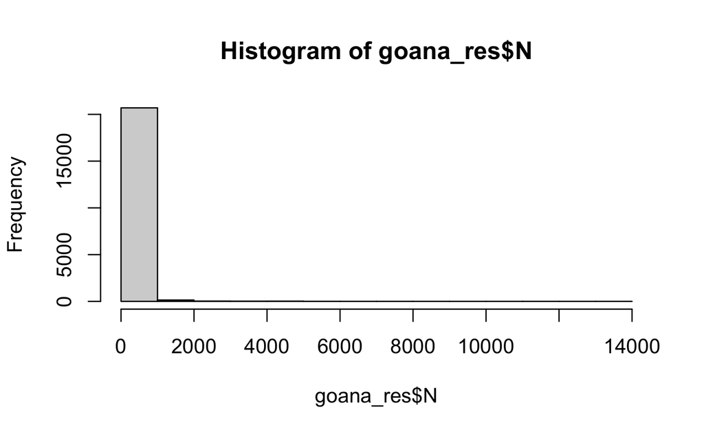

```r
hist(goana_res$N) # column N shows the number of genes in a GO term
```

Most GO terms have fewer than 1000 genes, let’s look only at those terms

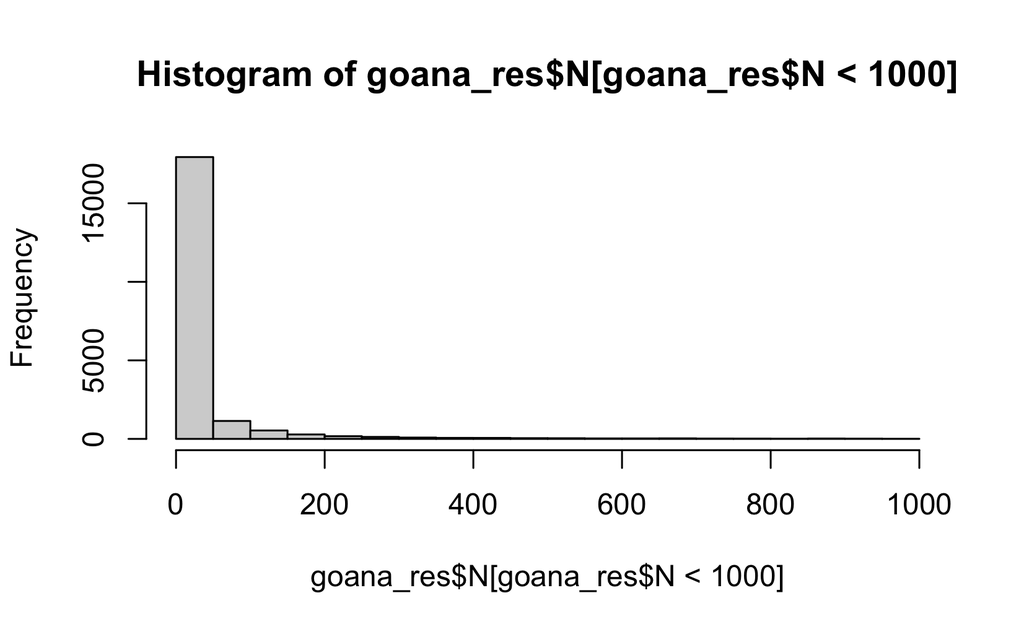

```r
hist(goana_res$N[goana_res$N < 1000])
```

Still a lot of genes! Let’s narrow down some more.

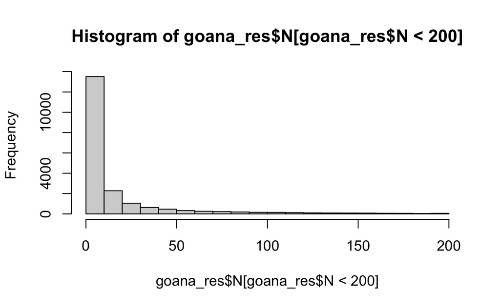

```r
hist(goana_res$N[goana_res$N < 200])
```

Now let’s filter our results dataframe based on the number of genes in a GO term and our FDR adjusted P value.

```r
goana_res %>%
  filter(Ont == "BP" & N < 200 & P.Up.adj < 0.05) -> goana_res_filt

goana_res_filt %>%
  slice_min( # "slices" N number of rows with minimum values based on a variable
    n = 10, # number of rows to slice
    order_by = P.Up.adj # variable to order by
  )
```

|  | Term | Ont | N | Up | Down | P.Up | P.Down | P.Up.adj | P.Down.adj |
| --- | --- | --- | --- | --- | --- | --- | --- | --- | --- |
| GO:0071222 | cellular response to lipopolysaccharide | BP | 150 | 50 | 2 | 3.155303e-22 | 0.9532219 | 7.873232e-20 | 1 |
| GO:0071216 | cellular response to biotic stimulus | BP | 182 | 55 | 3 | 5.243697e-22 | 0.9305472 | 1.293034e-19 | 1 |
| GO:0071219 | cellular response to molecule of bacterial origin | BP | 156 | 50 | 2 | 2.265507e-21 | 0.9602101 | 5.458050e-19 | 1 |
| GO:0032635 | interleukin-6 production | BP | 113 | 35 | 3 | 7.738827e-15 | 0.6982237 | 9.597978e-13 | 1 |
| GO:0032675 | regulation of interleukin-6 production | BP | 113 | 35 | 3 | 7.738827e-15 | 0.6982237 | 9.597978e-13 | 1 |
| GO:0034612 | response to tumor necrosis factor | BP | 187 | 44 | 1 | 1.715200e-13 | 0.9976400 | 1.797530e-11 | 1 |
| GO:0046651 | lymphocyte proliferation | BP | 198 | 44 | 3 | 1.432878e-12 | 0.9523264 | 1.323045e-10 | 1 |
| GO:0071356 | cellular response to tumor necrosis factor | BP | 168 | 40 | 1 | 1.455017e-12 | 0.9956207 | 1.337594e-10 | 1 |
| GO:1990868 | response to chemokine | BP | 45 | 20 | 0 | 2.155501e-12 | 1.0000000 | 1.930739e-10 | 1 |
| GO:1990869 | cellular response to chemokine | BP | 45 | 20 | 0 | 2.155501e-12 | 1.0000000 | 1.930739e-10 | 1 |

Let’s practice some more subsetting!

Let’s look for barely significant GO terms.

```r
goana_res %>%
  filter(P.Up.adj < 0.05 & P.Up.adj > 0.049)
```

|  | Term | Ont | N | Up | Down | P.Up | P.Down | P.Up.adj | P.Down.adj |
| --- | --- | --- | --- | --- | --- | --- | --- | --- | --- |
| GO:1902911 | protein kinase complex | CC | 143 | 19 | 6 | 0.003631997 | 0.2991901 | 0.04998468 | 1 |

Or we can look for some specific GO terms

|  | Term | Ont | N | Up | Down | P.Up | P.Down | P.Up.adj | P.Down.adj |
| --- | --- | --- | --- | --- | --- | --- | --- | --- | --- |
| GO:0009062 | fatty acid catabolic process | BP | 95 | 5 | 8 | 0.7799170570 | 0.01039119 | 1.00000000 | 1 |
| GO:0046349 | amino sugar biosynthetic process | BP | 13 | 2 | 0 | 0.2187944469 | 1.00000000 | 0.77108046 | 1 |
| GO:0010803 | regulation of tumor necrosis factor-mediated signaling pathway | BP | 53 | 11 | 0 | 0.0007152119 | 1.00000000 | 0.01327798 | 1 |

Let’s see how many downregulated GO terms there are

|  | Term | Ont | N | Up | Down | P.Up | P.Down | P.Up.adj | P.Down.adj |
| --- | --- | --- | --- | --- | --- | --- | --- | --- | --- |
| GO:0000981 | DNA-binding transcription factor activity, RNA polymerase II-specific | MF | 947 | 96 | 56 | 3.771108e-05 | 4.131955e-06 | 0.001113274 | 0.04330289 |
| GO:0003700 | DNA-binding transcription factor activity | MF | 1016 | 98 | 59 | 2.046341e-04 | 3.929322e-06 | 0.004651985 | 0.04330289 |

Not very many! We have chosen the `edgeR` FDR cutoff of 0.05 to define differentially expressed genes, which then defines the contingency tables. The results of the enrichment analysis will depend on the significance threshold that is used to assess differential expression. You can compare Fisher’s exact test results from different differential expression cutoffs as a good sanity check.

### Activities

#### Green 1

Identify GO terms that are almost significantly enriched. For example, look for GO terms with adjusted P values that are smaller than 0.07 but greater than 0.05.

#### Green 2

Try using different higher or lower FDR cutoffs in the `goana()` argument. How does this affect the enrichment results?

#### Blue 1

There is another function called `kegga()` which uses identical arguments to `goana()`. Use `kegga()` to perform KEGG pathway analysis.

How many KEGG pathways were identified?

What are the top 10 enriched KEGG pathways in upregulated genes?

What are the top 10 enriched KEGG pathways in downregulated genes?